# BIO 18 Project

# Group: JAM sandwich

Names:

- Julia Moeurn
- Anthony Lien
- Minhyuk Kim

**Introduction**

Our group decided to do some exploratory data analysis into March Madness so that we can discuss about increases in gambling or viewership and the average score that winning teams score. Our data comes from sportsmediawatch.com, ncaa.com, and boydsbets.com.

```r
#load data
library("readr")
gambling_data <- read_csv ("Amount of Bet on March Madness.csv")
winning_score_data <- read_csv ("NCAA Winning Team Score.csv")
viewership_data <- read_csv ("NCAA Championship vs NBA Finals Viewership.csv")

#load ggplot
library("ggplot2")
library("tidyverse")
```

# How is gambling for March Madness represented over time?

by Julia Moeurn

In this case, we observe how much has the gambling bets increased over time for March Madness, and in particular, the total money bet in Las Vegas Sportsbook was analyzed to see how much of a change there has been.

```r
#mean and standard deviation of Amount Bet on March Madness
Bet <- c(122313375.8, 136707368.42, 156422264.88, 182615803.81, 191171631.21, 174793893.13, 211248677.25, 205224043.72, 230928281.46, 259426847.66, 274831858.41, 300225806.45, 337788235.29, 351808012.49)
mean(Bet)
```

```
## [1] 223964721
```

```r
sd(Bet)
```

```
## [1] 71915334
```

```r
Year <- c(2004, 2005, 2006, 2007, 2008, 2009, 2010, 2011, 2012, 2013, 2014, 2015, 2016, 2017)

#correlation of Amount Bet on March Madness
cor.test(Year, Bet)
```

```
##
##  Pearson's product-moment correlation
##
## data:  Year and Bet
## t = 15.723, df = 12, p-value = 2.267e-09
## alternative hypothesis: true correlation is not equal to 0
## 95 percent confidence interval:
##  0.9255985 0.9927576
## sample estimates:
##       cor
## 0.9765773
```

mean: 223964721

SD: 71915334

Correlation: 0.9765773

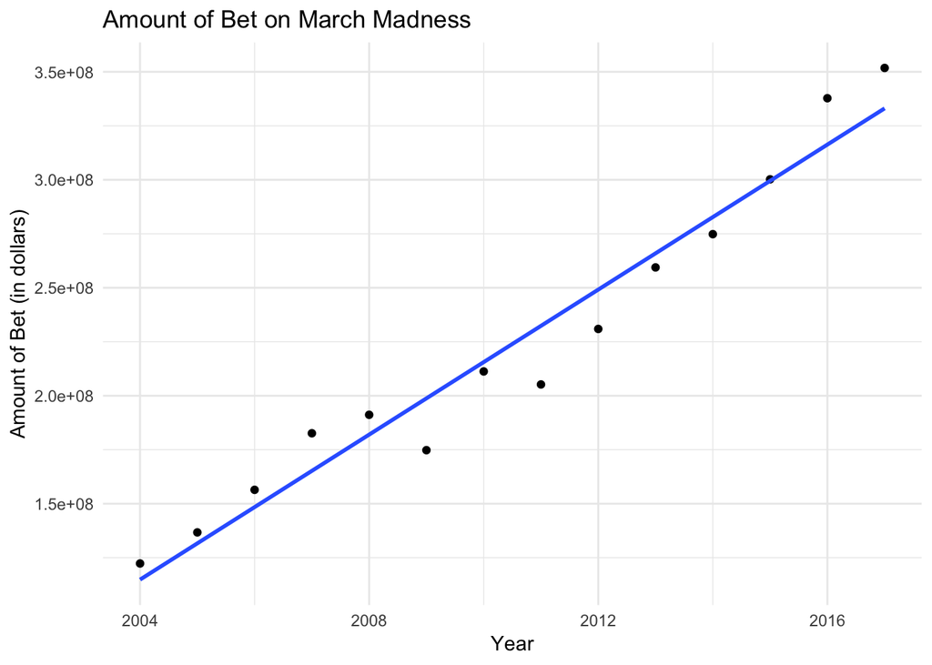

```r
df <- data.frame(Bet, Year)
ggplot(df, aes(x = Year , y = Bet)) +
geom_point() +
  geom_smooth(method = "lm", se = FALSE) + theme_minimal() +
  ggtitle("Amount of Bet on March Madness") +
  xlab("Year") +
  ylab("Amount of Bet (in dollars)")
```

With r = 0.9765773, the amount of bet each year is highly and positively correlated; thus, with each upcoming year we would expect an increase in the amount of bet.

# What is the average score that the winning teams score in the championship game?

by Anthony Lien

For this, we look at the the final scores of the championship games to find out what is the score that winning teams score on average.

```r
# sample statistics
Score <- c(89, 82, 64, 81, 82, 75, 73, 84, 75, 89, 61, 53, 67, 82, 60, 68, 77, 71, 79, 85)
Year2 <- c(2000, 2001, 2002, 2003, 2004, 2005, 2006, 2007, 2008, 2009, 2010, 2011, 2012, 2013, 2014, 2015, 2016, 2017, 2018, 2019)

mean(Score)
```

```
## [1] 74.85
```

```r
median(Score)
```

```
## [1] 76
```

```r
sd(Score)
```

```
## [1] 10.09051
```

mean: 74.85

median: 76

SD: 10.09051

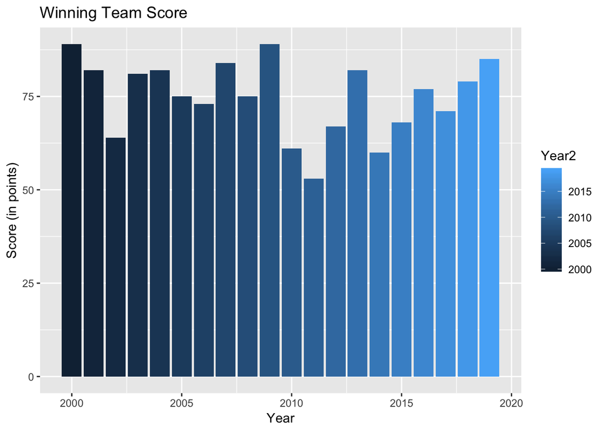

```r
df2 <- data.frame(Score, Year2)
ggplot(df2, aes(x = Year2 , y = Score, fill = Year2)) +
geom_bar(stat = "identity") +
  labs(title = "Winning Team Score",
       x = "Year", y = "Score (in points)")
```

In the years of 2000 to 2019, the winning teams of the NCAA championship scored an average of about 74.85 points (median: about 76 points) with a standard deviation of roughly 10.09051 points.

In the case that a winning team scores less than 50 points, the probability of that occuring could be calculated through a probability distribution plot as such:

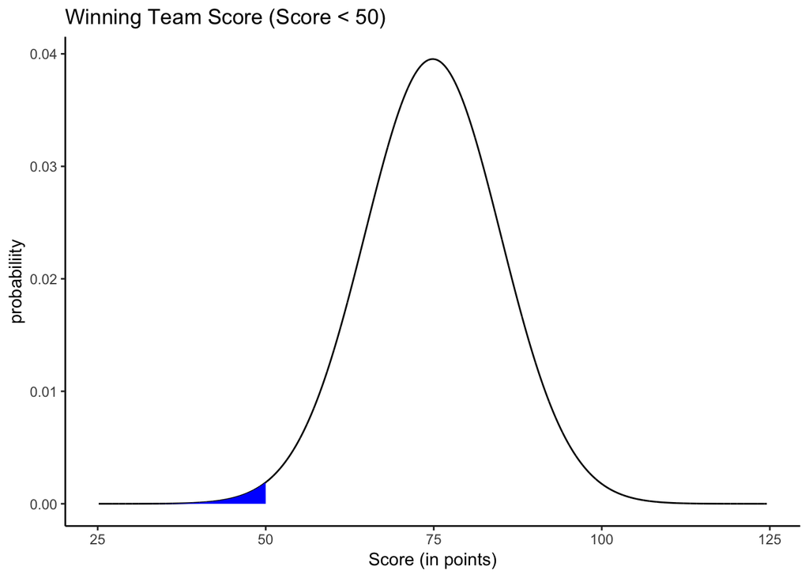

```r
x <- seq(25.15, 124.55, 0.01)

y <- dnorm(x, mean = 74.85, sd = 10.09051)

df <- data.frame(x,y)

bell <- ggplot(df, aes(x, y)) +
  geom_line() +
  theme_classic() +
  xlab("Score (in points)") +
  ylab("probabiliity")

shade <- rbind( c(min(x), 0), subset(df, x < 50), c(50, 0))

bell +
  ggtitle("Winning Team Score (Score < 50)") +
  geom_polygon(data = shade, aes(x,y), fill = "blue")
```

$$P(Score < 50)$$
The probability that a winning team scores less than 50 points in the championship game is 0.0069.

# How much does the viewership of the March Madness championship differ from that of the NBA finals?

by Minhyuk Kim

Here we look at the average viewership of the NCAA championship compared to the average viewership of each game of the NBA finals.

```r
#mean and standard deviation of NCAA chmapionship viewership
ncaa <- c(20.587, 23.97, 23.686, 18.573, 17.088, 23.895, 17.543, 19.563, 19.501, 17.649, 23.944, 20.055, 20.896, 23.426, 21.196, 28.263, 17.752, 22.998, 16.5)
mean(ncaa)
```

```
## [1] 20.89921
```

```r
sd(ncaa)
```

```
## [1] 3.127989
```

```r
#mean and standard deviation of average NBA finals viewership
nba <- c(17.9275, 18.982, 15.6675, 9.827, 17.968, 12.62, 12.96, 9.29, 14.903, 14.286, 18.1357, 17.3933, 16.848, 17.4743,  15.544, 19.9433, 20.2829, 20.432, 17.5575)
mean(nba)
```

```
## [1] 16.21274
```

```r
sd(nba)
```

```
## [1] 3.242366
```

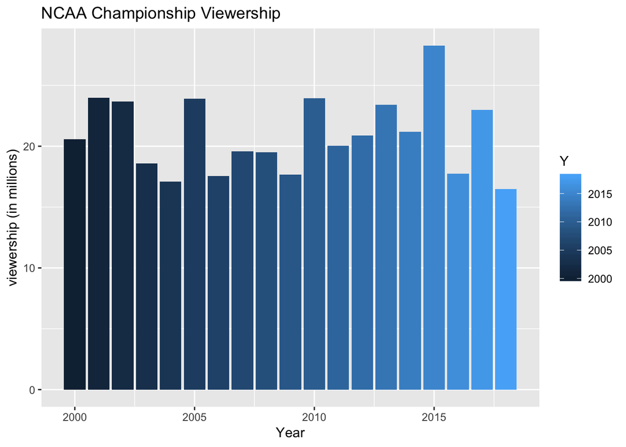

```r
#ggplot for NCAA
Y <- c(2000, 2001, 2002, 2003, 2004, 2005, 2006, 2007, 2008, 2009, 2010, 2011, 2012, 2013, 2014, 2015, 2016, 2017, 2018)
df <- data.frame(ncaa, Y)
ggplot(df, aes(x = Y, y = ncaa, fill = Y)) +
  geom_bar(stat = "identity") +
  labs(title = "NCAA Championship Viewership",
      x = "Year", y = "viewership (in millions)")
```

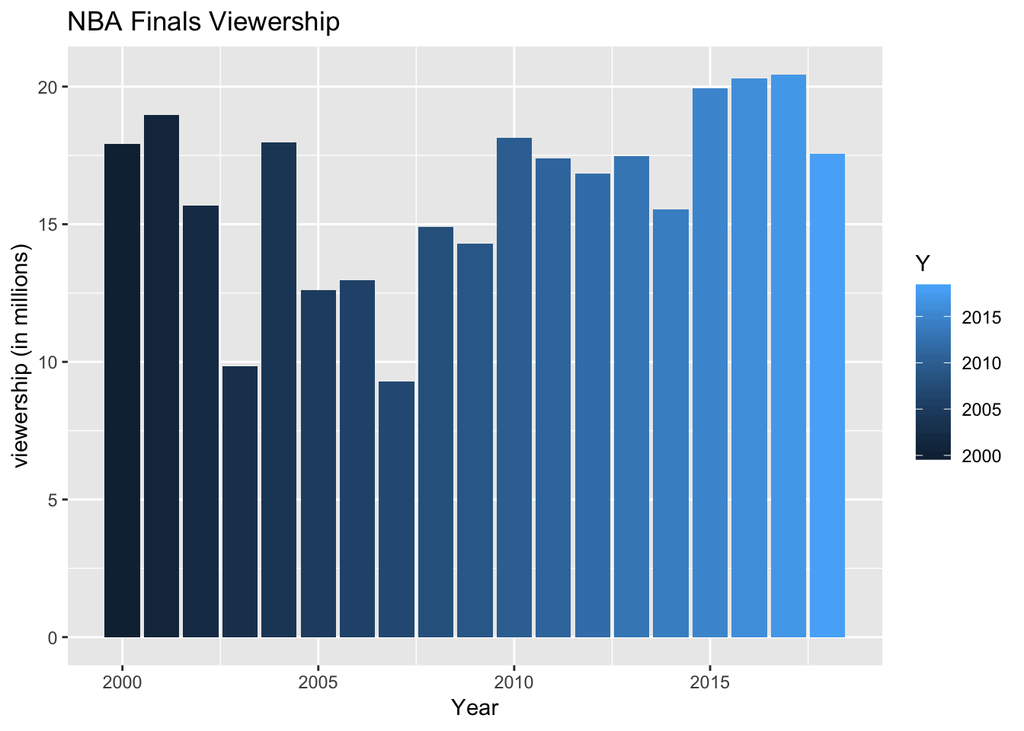

```r
#ggplot for NBA
df2 <- data.frame(nba, Y)
ggplot(df2, aes(x = Y , y = nba, fill = Y)) +
geom_bar(stat = "identity") +
  labs(title = "NBA Finals Viewership",
       x = "Year", y = "viewership (in millions)")
```

mean (NCAA) = 20.89921

SD (NCAA) = 3.127989

mean (NBA) = 16.21274

SD (NBA) = 3.242366

The difference in average viewership of the NCAA championship compared to the average viewership of the NBA final games is roughly 4.68647 million. This would mean that the NCAA championship garners a much larger viewership in its championship game on average compared to the viewership of the NBA finals game.